# Pràctica 2

### 4.2. Comprovació de la normalitat i homogeneïtat de la variància.

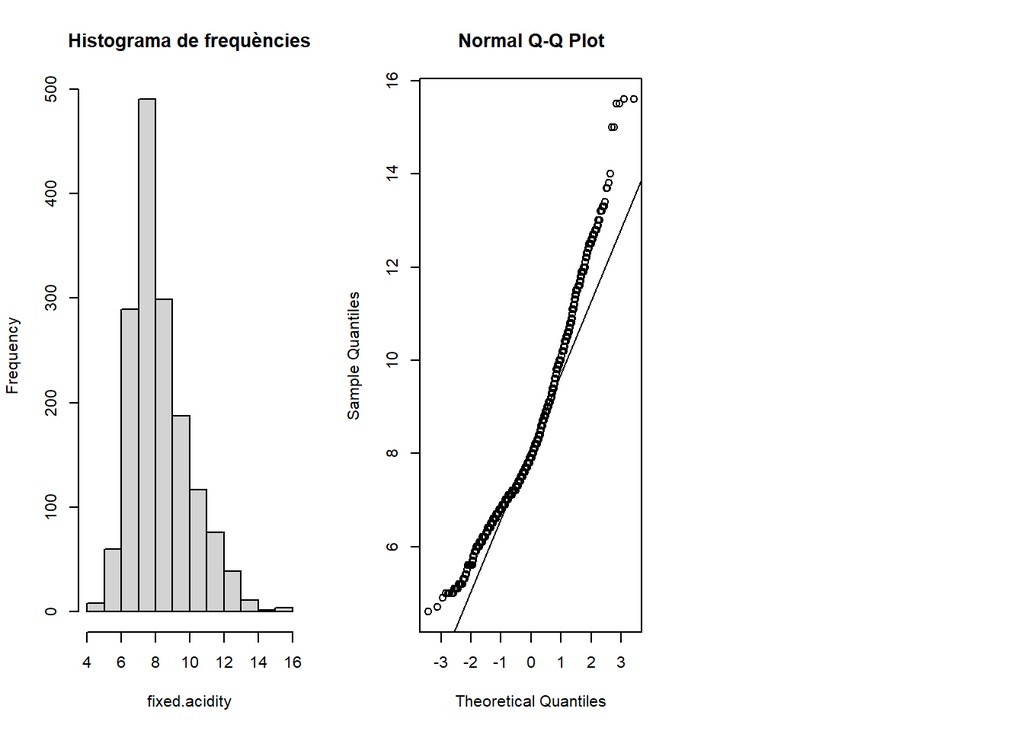

```
## [1] "test de Saphiro-Wilk de la variable  fixed.acidity  és  0.00000000000000000000000574049506505455"
```

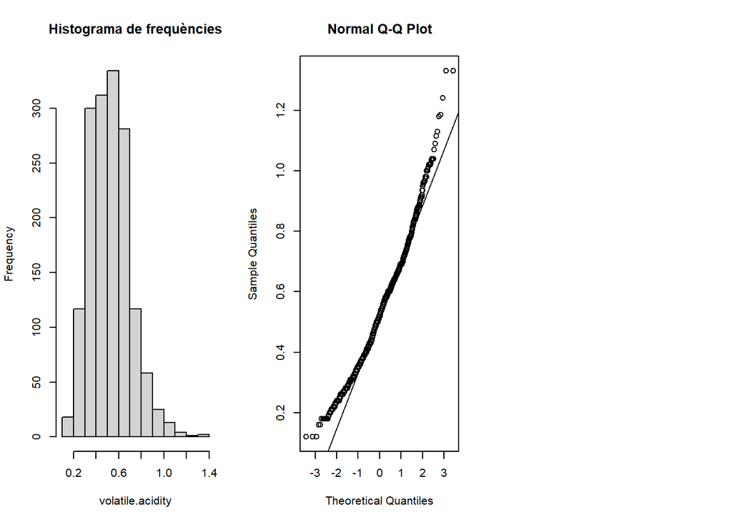

```
## [1] "test de Saphiro-Wilk de la variable  volatile.acidity  és  0.0000000000000178662147025067"
```

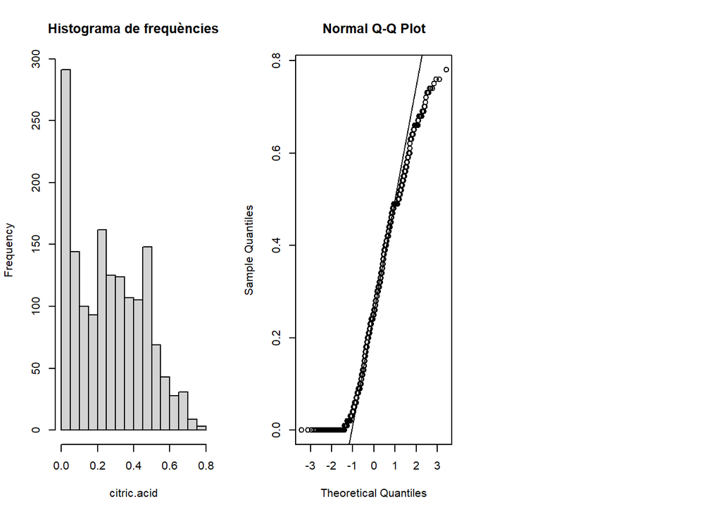

```
## [1] "test de Saphiro-Wilk de la variable  citric.acid  és  0.000000000000000000000704334097034468"
```

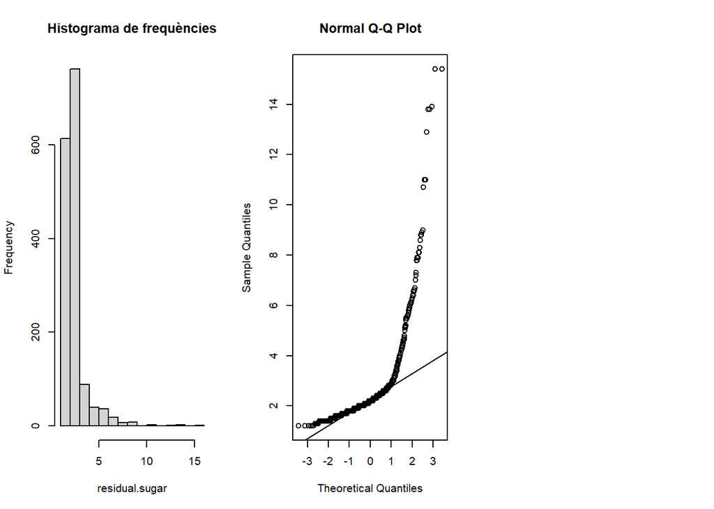

```
## [1] "test de Saphiro-Wilk de la variable  residual.sugar  és  0.00000000000000000000000000000000000000000000000000057590978574169"
```

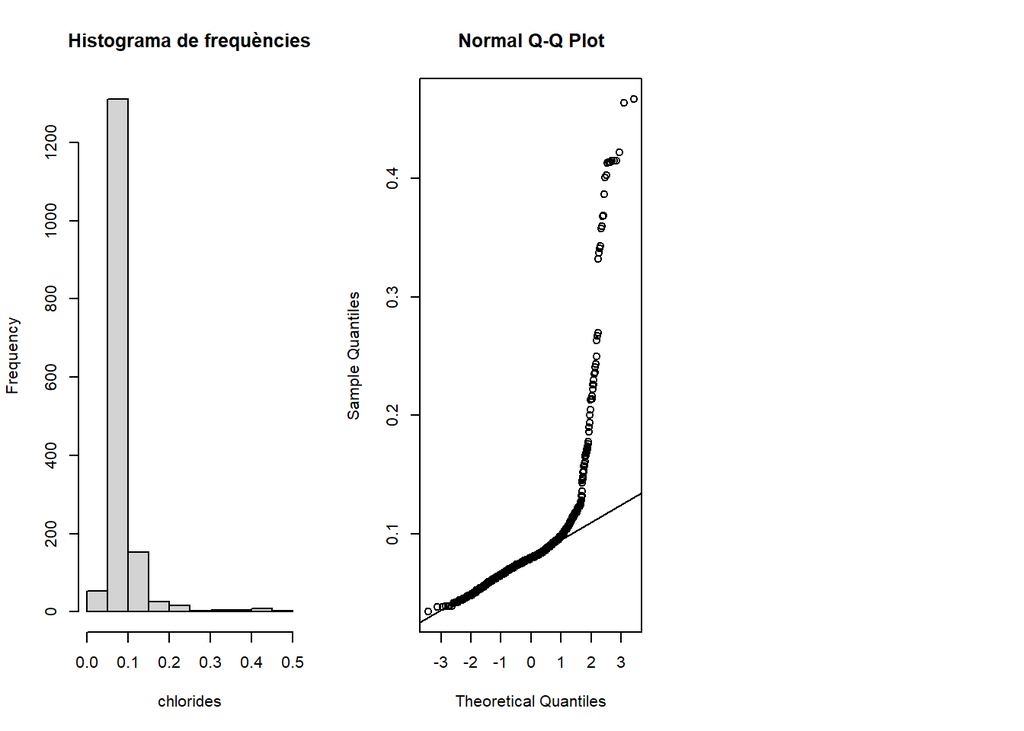

```
## [1] "test de Saphiro-Wilk de la variable  chlorides  és  0.0000000000000000000000000000000000000000000000000000014871302997056"
```

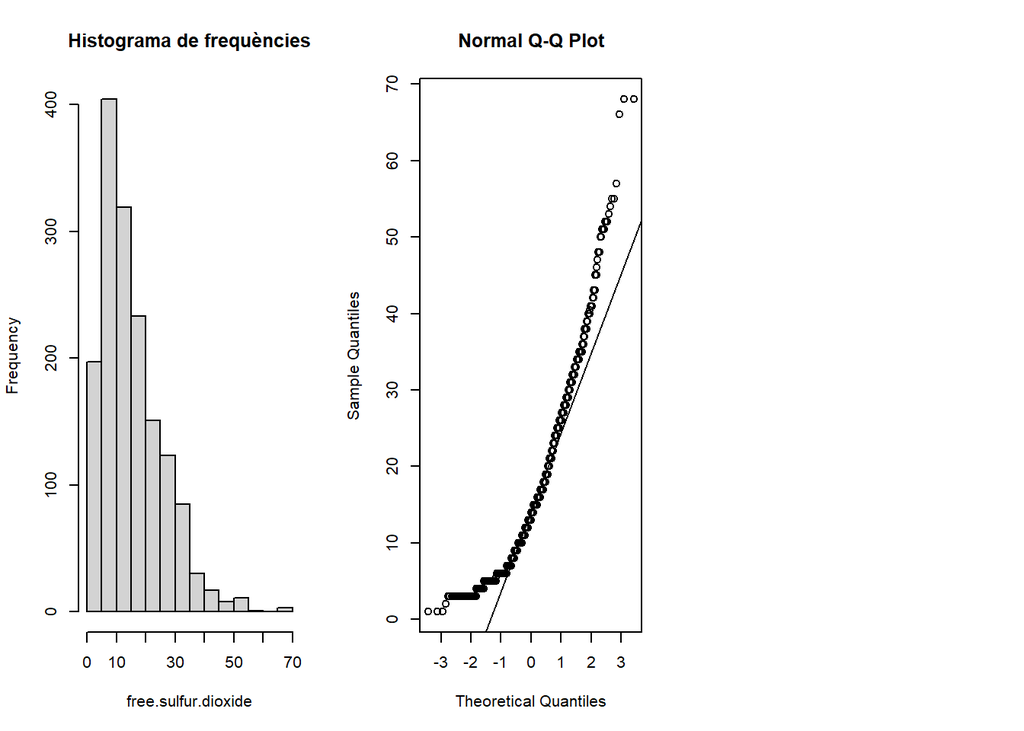

```
## [1] "test de Saphiro-Wilk de la variable  free.sulfur.dioxide  és  0.00000000000000000000000000000228038871510153"
```

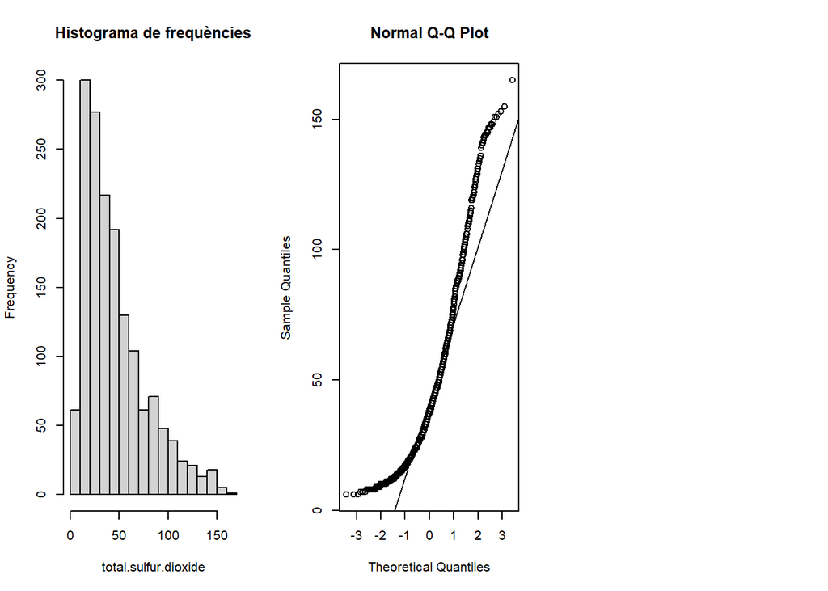

```
## [1] "test de Saphiro-Wilk de la variable  total.sulfur.dioxide  és  0.0000000000000000000000000000000349197327160751"
```

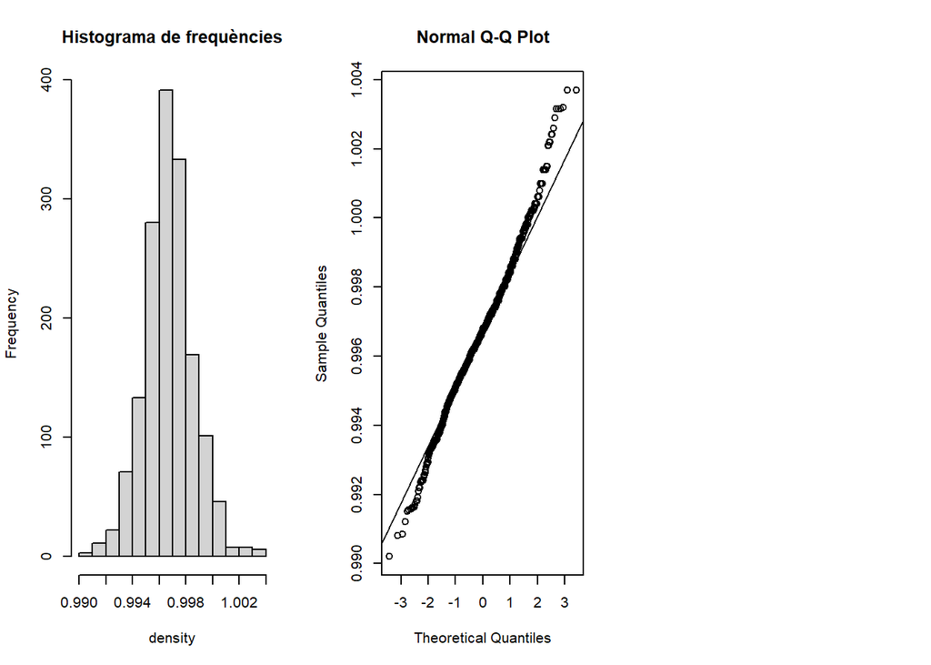

```
## [1] "test de Saphiro-Wilk de la variable  density  és  0.000000198457486312986"
```

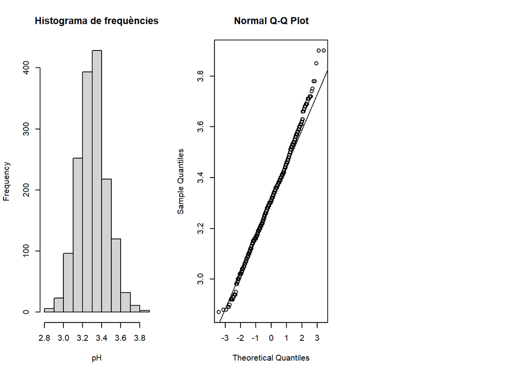

```
## [1] "test de Saphiro-Wilk de la variable  pH  és  0.000456029891682251"
```

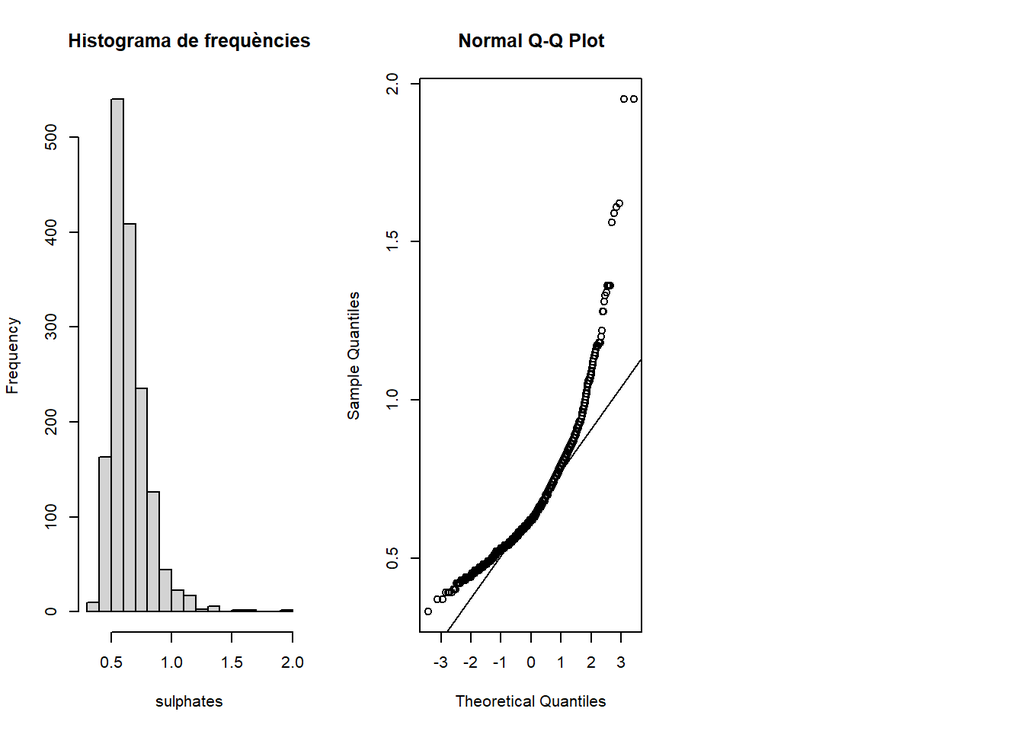

```
## [1] "test de Saphiro-Wilk de la variable  sulphates  és  0.0000000000000000000000000000000000171902264175559"
```

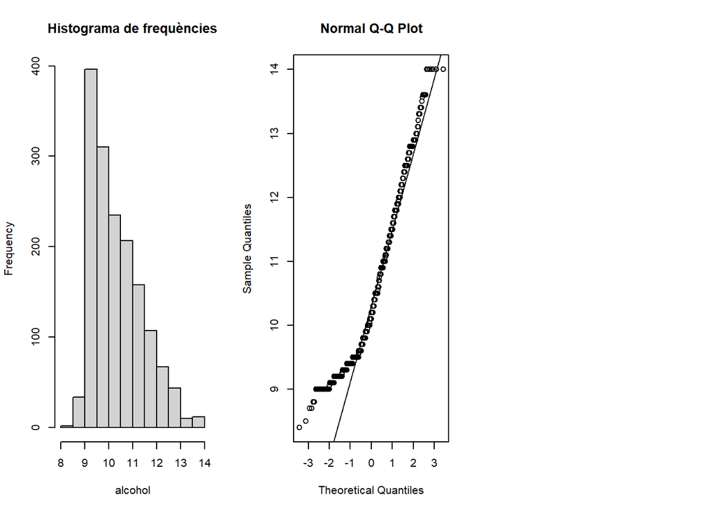

```
## [1] "test de Saphiro-Wilk de la variable  alcohol  és  0.00000000000000000000000000810985011996217"
```

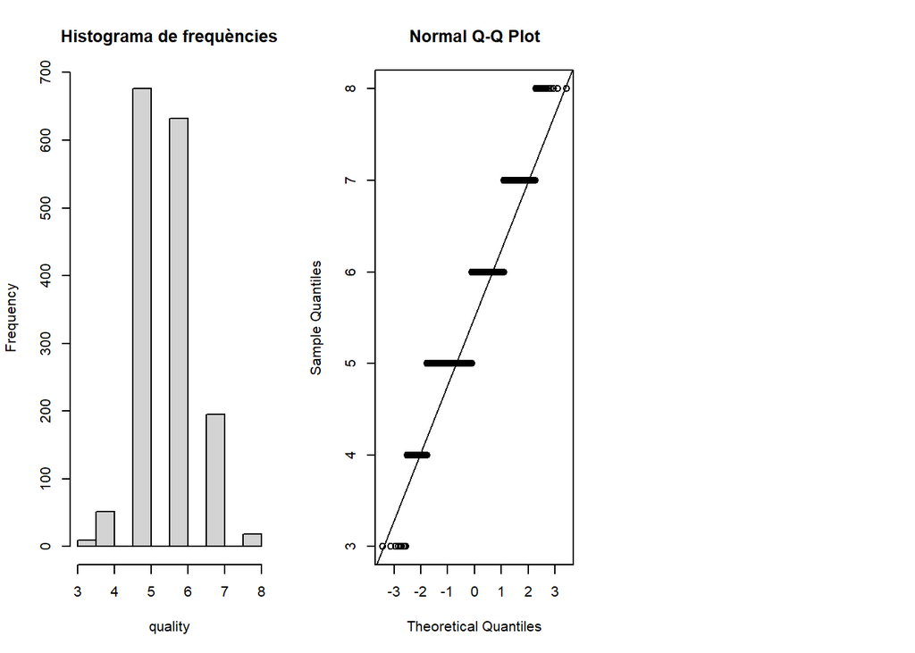

```
## [1] "test de Saphiro-Wilk de la variable  quality  és  0.0000000000000000000000000000000000103947017448143"
```

```
## [1] "test de Saphiro-Wilk de la variable  qualitat_excellent  és  0.000000000000000000000000000000000000000000000000000000000547525639996855"
```

[1 more figures not shown]

```r
# anàlisi de la normalitat per cada variable:

  alpha <- 0.05

  for(x in colnames(df)) {

      # Diagrames de densidad
      par(mfrow=c(1,3))
      hist(df[,x],main = "Histograma de frequències",xlab = x) # histograma
      qqnorm(df[,x]) # gràfic quantile
      qqline(df[,x])


      # Test de Saphiro-Wilk

      pvalue <- shapiro.test(df[,x])$p.value
      print(paste('test de Saphiro-Wilk de la variable ', x , ' és ',pvalue))

   }
```

Fent el diagrama de frequències i el Q-Q plot amb totes les variables, tot i que tenim gràfiques on no s’ajusten a la línia de la distribució teòrica i prenen una distribució exponencial.

Fent el contrast amb el test de Saphiro-Wilk, tots els pvalue són per sota de 0.05, com a interval de confiança, que ens diria que tenen una distribució no normal.

Pel Teorema del Límit Central, degut al volum de dades, podem asumir que la mitjana mostral segueix una distribució normal.

A l’apartat on fem contrast d’hipòtesi analitzem la variança.

### 4.3. Aplicació de proves estadístiques per comparar els grups de dades. En funció de les dades i de l’objectiu de l’estudi, aplicar proves de contrast d’hipòtesis, correlacions, regressions, etc. Aplicar almenys tres mètodes d’anàlisi diferents.

Correlacions

```r
set.seed(123)

cor(df) %>%
  as.data.frame() %>%
  mutate(var1 = rownames(.)) %>%
  gather(var2, value, -var1) %>%
  arrange(desc(value)) %>%
  group_by(value) %>%
  filter(row_number()==1)
```

```
## # A tibble: 79 x 3
## # Groups:   value [79]
##    var1                 var2                value
##    <chr>                <chr>               <dbl>
##  1 fixed.acidity        fixed.acidity       1
##  2 qualitat_excellent   quality             0.711
##  3 citric.acid          fixed.acidity       0.674
##  4 density              fixed.acidity       0.674
##  5 total.sulfur.dioxide free.sulfur.dioxide 0.667
##  6 quality              alcohol             0.483
##  7 qualitat_excellent   alcohol             0.411
##  8 density              citric.acid         0.371
##  9 density              residual.sugar      0.367
## 10 sulphates            chlorides           0.326
## # ... with 69 more rows
```

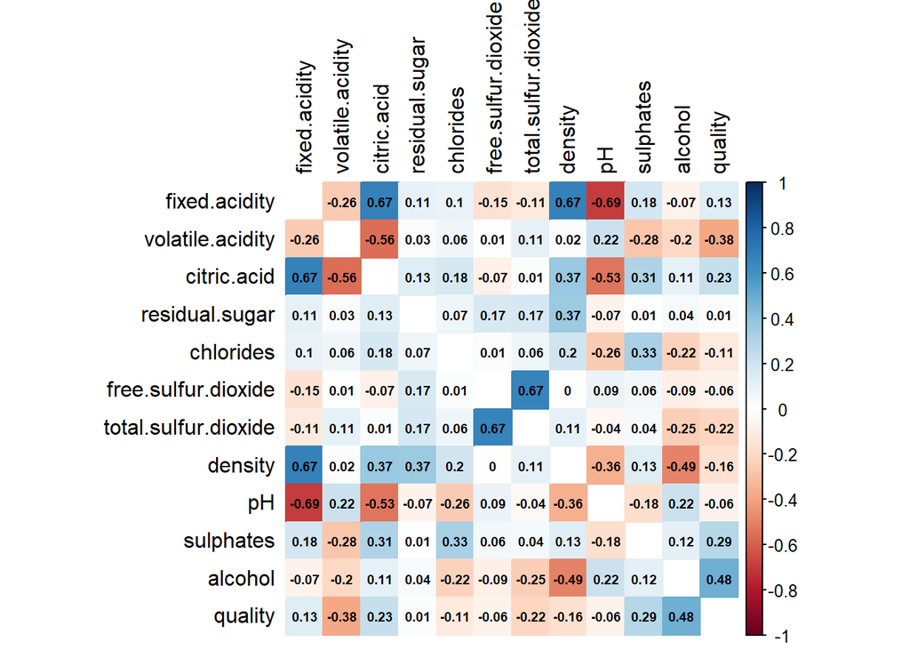

```r
dfcor <- cor(df[,-13])
corrplot(dfcor, method = "color", addCoef.col = "black",number.cex = .6, tl.col = "black", tl.srt = 90, diag = FALSE)
```

Les variables que més influeixen en la qualitat del vi són l’alcohol, volatile.acidity, sulphates, citric.acid i total.sulfur.dioxide

Contrast d’hipòtesis

Treballarem amb preguntes relacionades amb la influència respecte de la qualitat del vi. Fem dos conjunts, un de bons i altre de no tan bons vins i plantegem les qüestions:

```r
# separació en dos conjunts vi_bo i vi_dolent

vi_bo <- df$alcohol[df$qualitat_excellent==1]
vi_dolent <- df$alcohol[df$qualitat_excellent==0]
```

Analitzarem la variable més influent, i ens preguntem: diferència entre la graduació de alcohol per veure si els bons vins tenen més alcohol que els dolents

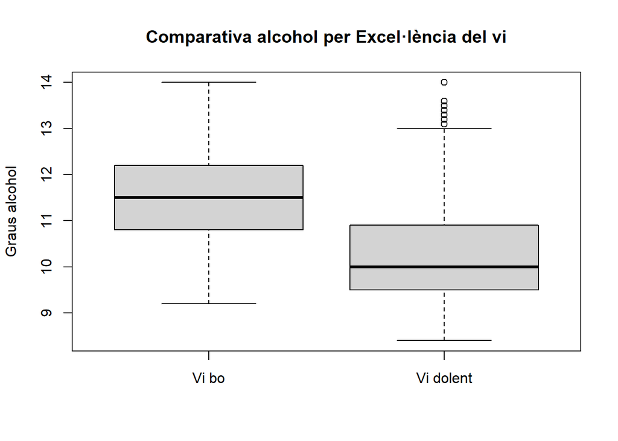

```r
# fem una anàlisi visual

# diagrama de caixa. notch = TRUE representa ic = 95%

boxplot(vi_bo,vi_dolent, main = "Comparativa alcohol per Excel·lència del vi",
          ylab = "Graus alcohol", names = c("Vi bo","Vi dolent"))
```

La mitjana al vi bo visualment és per sobre de la mitjana al vi dolent. Ho comprovem amb el test.

Es tracta d’una comparació de mitjanes en poblacions normals independents: H0 : μ1 − μ2 = 0 H1 : μ1 − μ2 > 0 on μ1 denota la mitjana de graus alcohol per vi bo i μ2 la mitjana de graus alcohol per vi dolent.

Com que pel TLC (Teorema límit central) hem vist que asumim la normalitat, estudiem la homocedasticitat de la variança.

```r
var.test(vi_bo, vi_dolent)
```

```
##
##  F test to compare two variances
##
## data:  vi_bo and vi_dolent
## F = 1.1127, num df = 212, denom df = 1368, p-value = 0.2887
## alternative hypothesis: true ratio of variances is not equal to 1
## 95 percent confidence interval:
##  0.9134803 1.3765301
## sample estimates:
## ratio of variances
##           1.112661
```

El contrast de variàncies ens mostra un valor p més gran que 0.05 i per tant es pot assumir igualtat de variàncies en les dues poblacions.

```r
# contrast
d <- 0 # Diferència entre mitjanes
t.test(vi_bo, vi_dolent, alternative="greater", mu = d, var.equal=FALSE)
```

```
##
##  Welch Two Sample t-test
##
## data:  vi_bo and vi_dolent
## t = 17.244, df = 274.6, p-value < 0.00000000000000022
## alternative hypothesis: true difference in means is greater than 0
## 95 percent confidence interval:
##  1.145774      Inf
## sample estimates:
## mean of x mean of y
##  11.50900  10.24195
```

Resposta: El pvalor del test (0) és inferior al nivell de significació (0.05). Per tant, podem rebutjar la hipòtesi nul·la a favor de l’alternativa i podem concloure que en mitjana la graduació d’alcohol als vins bons és més gran que als vins dolents.

Regressió:

Primer farem un estudi per avaluar un model lineal que expliqui la variable quality en funció de l’alcohol

```r
lm0 <- lm(quality ~ alcohol, data = df)
summary(lm0)
```

```
##
## Call:
## lm(formula = quality ~ alcohol, data = df)
##
## Residuals:
##     Min      1Q  Median      3Q     Max
## -2.8527 -0.4065 -0.1850  0.5164  2.5902
##
## Coefficients:
##             Estimate Std. Error t value            Pr(>|t|)
## (Intercept)  1.79226    0.17619   10.17 <0.0000000000000002 ***
## alcohol      0.36914    0.01684   21.93 <0.0000000000000002 ***
## ---
## Signif. codes:  0 '***' 0.001 '**' 0.01 '*' 0.05 '.' 0.1 ' ' 1
##
## Residual standard error: 0.7043 on 1580 degrees of freedom
## Multiple R-squared:  0.2333, Adjusted R-squared:  0.2328
## F-statistic: 480.8 on 1 and 1580 DF,  p-value: < 0.00000000000000022
```

El coeficient de determinació té un valor 0,2333, això vol dir que el nostre model ens explica només el 23,33% de variància de les observacions.

Afegim les altres 4 variables més relacionades per veure si millora el model

```r
lm1 <- lm(quality ~ alcohol + volatile.acidity +  sulphates + citric.acid + total.sulfur.dioxide, data = df)
summary(lm1)
```

```
##
## Call:
## lm(formula = quality ~ alcohol + volatile.acidity + sulphates +
##     citric.acid + total.sulfur.dioxide, data = df)
##
## Residuals:
##      Min       1Q   Median       3Q      Max
## -2.75874 -0.37625 -0.05829  0.44337  2.10871
##
## Coefficients:
##                        Estimate Std. Error t value             Pr(>|t|)
## (Intercept)           2.6772111  0.2077515  12.887 < 0.0000000000000002 ***
## alcohol               0.2954504  0.0163043  18.121 < 0.0000000000000002 ***
## volatile.acidity     -1.1032193  0.1140315  -9.675 < 0.0000000000000002 ***
## sulphates             0.8857491  0.1069826   8.279 0.000000000000000261 ***
## citric.acid           0.0143854  0.1037951   0.139                 0.89
## total.sulfur.dioxide -0.0026209  0.0005368  -4.883 0.000001152727724423 ***
## ---
## Signif. codes:  0 '***' 0.001 '**' 0.01 '*' 0.05 '.' 0.1 ' ' 1
##
## Residual standard error: 0.6472 on 1576 degrees of freedom
## Multiple R-squared:  0.3543, Adjusted R-squared:  0.3523
## F-statistic:   173 on 5 and 1576 DF,  p-value: < 0.00000000000000022
```

El coeficient de determinació té un valor 0.3543, això vol dir que el nostre model ens explica només el 35,43 % de variància de les observacions. Millora el model fent servir només l’alcohol

```r
df2 = df

##Normalitzem les variables per poder aplicar el SVM

df2$alcohol <- df2$alcohol /max(df2$alcohol)
df2$volatile.acidity <- df2$volatile.acidity /max(df2$volatile.acidity)
df2$sulphates <- df2$sulphates /max(df2$sulphates)
df2$citric.acid <- df2$citric.acid /max(df2$citric.acid)
df2$total.sulfur.dioxide <- df2$total.sulfur.dioxide /max(df2$total.sulfur.dioxide)

sample_data = sample.split(df2, SplitRatio = 0.8)
train_data <- subset(df2, sample_data == TRUE)
test_data <- subset(df2, sample_data == FALSE)

svm1 = svm(formula = qualitat_excellent ~ alcohol + volatile.acidity +  sulphates + citric.acid + total.sulfur.dioxide, data = train_data,
                 type = 'C-classification',
                 kernel = 'sigmoid')

pred<-predict(svm1, test_data)

confusionMatrix(table(pred, test_data$qualitat_excellent))
```

```
## Confusion Matrix and Statistics
##
##
## pred   0   1
##    0 290  38
##    1  25  12
##
##                Accuracy : 0.8274
##                  95% CI : (0.7846, 0.8647)
##     No Information Rate : 0.863
##     P-Value [Acc > NIR] : 0.9774
##
##                   Kappa : 0.1804
##
##  Mcnemar's Test P-Value : 0.1306
##
##             Sensitivity : 0.9206
##             Specificity : 0.2400
##          Pos Pred Value : 0.8841
##          Neg Pred Value : 0.3243
##              Prevalence : 0.8630
##          Detection Rate : 0.7945
##    Detection Prevalence : 0.8986
##       Balanced Accuracy : 0.5803
##
##        'Positive' Class : 0
##
```

En concret, hem encertat 302 prediccions i n’hem fallat 63. Hem obtingut 25 falsos positius i 38 falsos negatius. El major problema és que el model té tendència a dir que el vi no és de qualitat excel·lent, llavors normalment encerta perquè la majoria de vins no són excel·lents, però si ens fixem en els positius veiem que n’encerta una minoria (12 de 50 = 24%).

```r
svm1 = svm(formula = quality ~ alcohol + volatile.acidity +  sulphates + citric.acid + total.sulfur.dioxide, data = train_data,
                 type = 'C-classification',
                 kernel = 'sigmoid')

pred<-predict(svm1, test_data)

confusionMatrix(table(pred, test_data$quality))
```

```
## Confusion Matrix and Statistics
##
##
## pred   3   4   5   6   7   8
##    3   0   0   0   0   0   0
##    4   0   0   2   0   0   0
##    5   0   4 103  67   8   1
##    6   1   4  57  51  29   3
##    7   0   0  10  16   8   1
##    8   0   0   0   0   0   0
##
## Overall Statistics
##
##                Accuracy : 0.4438
##                  95% CI : (0.3921, 0.4965)
##     No Information Rate : 0.4712
##     P-Value [Acc > NIR] : 0.8646
##
##                   Kappa : 0.0822
##
##  Mcnemar's Test P-Value : NA
##
## Statistics by Class:
##
##                      Class: 3 Class: 4 Class: 5 Class: 6 Class: 7 Class: 8
## Sensitivity           0.00000 0.000000   0.5988   0.3806  0.17778   0.0000
## Specificity           1.00000 0.994398   0.5855   0.5931  0.91563   1.0000
## Pos Pred Value            NaN 0.000000   0.5628   0.3517  0.22857      NaN
## Neg Pred Value        0.99726 0.977961   0.6209   0.6227  0.88788   0.9863
## Prevalence            0.00274 0.021918   0.4712   0.3671  0.12329   0.0137
## Detection Rate        0.00000 0.000000   0.2822   0.1397  0.02192   0.0000
## Detection Prevalence  0.00000 0.005479   0.5014   0.3973  0.09589   0.0000
## Balanced Accuracy     0.50000 0.497199   0.5922   0.4868  0.54670   0.5000
```

Si enlloc de comprovar que la qualitat sigui excel·lent intentem predir la qualitat veiem que per vins de qualitat notable (5-7) sol apropar-se al valor real. És cert que la accuracy, sensibilitat… són força dolentes, però l’error no és tan gran, sobretot en qualitats notables. És a dir, un vi que té qualitat 6 sol predir que té qualitat 5, 6 o 7. En altres paraules, el model seria força bo per estimar els vins de qualitat mitja-alta permetent-li un marge d’error de 1 punt per sobre o per sota.

Una de les possibles raones de per què el model no és gens bo amb qualitats fora del rang 5-7 podria ser que la gran majoria de registres tenen valors entre 5 i 7, de manera que hi ha una sobrerepresentació d’aquestes qualitats i una sotarepresentació d ela resta de qualitats. Això fa que el model s’ajusti millor per qualitats 5-7 i no pas tan per altres qualitats que estan sotarepresentades.

## 6. Resolució del problema. A partir dels resultats obtinguts, quines són les conclusions? Els resultats permeten respondre al problema?

Finalment, podem concloure que com majors són els valors de citric.acid, sulphates i alcohol més qualitat sol tenir el vi. D’altra banda, com menors siguin els valors de volatile.acidity i total.sulfur.dioxide el vi també té tendència a ser de major qualitat.

Els models predicitus no han obtingut massa bons resultats. Tanmateix, en el cas de SVM sí que obtenia uns resultats força bons a l’hora d’estimar vins de qualitat mitja-alta.

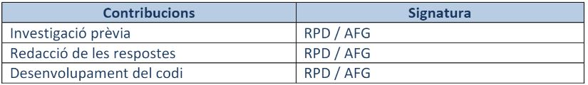

Taula de contribucions